# COVID Tracking Project - Updated for 2021

```r
}



# Helper function to make the overall cluster summary statistics
helperClusterSummaryPlots <- function(dfState,
                                      dfPlot,
                                      showMap,
                                      clusterPlotsTogether,
                                      weightedMean=TRUE,
                                      mapLevel="states"
                                      ) {

    # FUNCTION ARGUMENTS:
    # dfState: contains the state/county-level data
    # dfPlot: contains the joined data for plotting
    # showMap: boolean for whether to create a map (if FALSE, segment membership counts are shown instead)
    # clusterPlotsTogether: boolean, whether to put all four plots on the same page
    # weightedMean: boolean, whether to create weighted mean by segment (if FALSE, median by segment is taken)
    # mapLevel: the level to be used on the map

    # Reorder the cluster levels in dfState to match dfPlot
    # Convert factor order to match dfPlot (can be reordered by argument to the calling function)
    dfState <- dfState %>%
        mutate(cluster=factor(cluster, levels=levels(dfPlot$cluster)))

    # Plot the segments on a map or show segment membership
    if (showMap) {
        if (mapLevel=="counties") {
            dfMap <- dfState %>%
                mutate(fips=stringr::str_pad(state, width=5, side="left", pad="0")) %>%
                select(fips, cluster)
        } else {
            dfMap <- dfState
        }
        # Create the map
        p1 <- usmap::plot_usmap(regions=mapLevel, data=dfMap, values="cluster") +
            scale_fill_discrete("cluster") +
            theme(legend.position="right")
    } else {
        p1 <- dfState %>%
            count(cluster) %>%
            ggplot(aes(x=fct_rev(cluster), y=n)) +
            geom_col(aes(fill=cluster)) +
            geom_text(aes(y=n/2, label=n)) +
            coord_flip() +
            labs(x="", y="# Counties", title="Membership by segment")
    }

    # Plot the population totals by segment
    # Show population totals by cluster
    p2 <- dfState %>%
        group_by(cluster) %>%
        summarize(pop=sum(pop)/1000000, .groups="drop") %>%
        ggplot(aes(x=fct_rev(cluster), y=pop)) +
        geom_col(aes(fill=cluster)) +
        geom_text(aes(y=pop/2, label=round(pop))) +
        labs(y="Population (millions)", x="Cluster", title="Population by cluster (millions)") +
        coord_flip()

    # Plot the rolling 7-day mean daily disease burden by cluster
    # Create the p3Data to be either median of all elements in cluster or weighted mean
    p3 <- dfPlot %>%
        select(date, cluster, cases=cpm7, deaths=dpm7, pop) %>%
        pivot_longer((-c(date, cluster, pop))) %>%
        filter(!is.na(value)) %>%
        group_by(date, cluster, name) %>%
        summarize(mdnValue=median(value), wtdValue=sum(pop*value)/sum(pop), .groups="drop") %>%
        ggplot(aes(x=date, y=if(weightedMean) wtdValue else mdnValue)) +
        geom_line(aes(group=cluster, color=cluster)) +
        facet_wrap(~name, scales="free_y") +
        labs(x="",
             y="Rolling 7-day mean, per million",
             title="Rolling 7-day mean daily disease burden, per million",
             subtitle=paste0(if(weightedMean) "Weighted mean" else "Median",
                             " per day for states assigned to cluster"
             )
        ) +
        scale_x_date(date_breaks="1 months", date_labels="%b")

    # Plot the total cases and total deaths by cluster
    p4 <- dfPlot %>%
        group_by(cluster) %>%
        summarize(cases=sum(cases), deaths=sum(deaths), .groups="drop") %>%
        pivot_longer(-cluster) %>%
        ggplot(aes(x=fct_rev(cluster), y=value/1000)) +
        geom_col(aes(fill=cluster)) +
        geom_text(aes(y=value/2000, label=round(value/1000))) +
        coord_flip() +
        facet_wrap(~varMapper[name], scales="free_x") +
        labs(x="Cluster", y="Burden (000s)", title="Total cases and deaths by segment")

    # Place the plots together if plotsTogether is TRUE, otherwise just print
    if (isTRUE(clusterPlotsTogether)) {
        gridExtra::grid.arrange(p1, p2, p3, p4, nrow=2, ncol=2)
    } else {
        print(p1); print(p2); print(p3); print(p4)
    }

}



# Helper function to make total and per capita by state (calls its own helper function)
helperCallTotalPerCapita <- function(dfPlot,
                                     thruLabel
                                     ) {

    # FUNCTION ARGUMENTS:
    # dfPlot: the plotting data frame
    # thruLabel: the date that data are through

    # Plot total cases and total deaths by state, colored by cluster
    helperBarDeathsCases(dfPlot,
                         numVars=c("cases", "deaths"),
                         title=paste0("Coronavirus impact by state through ", thruLabel),
                         xVar=c("state"),
                         fillVar=c("cluster")
    )

    # Plot cases per million and deaths per million by state, colored by cluster
    helperBarDeathsCases(dfPlot,
                         numVars=c("cpm", "dpm"),
                         title=paste0("Coronavirus impact by state through ", thruLabel),
                         xVar=c("state"),
                         fillVar=c("cluster")
    )

}



# Helper function to make recent vs. total plots
helperCallRecentvsTotal <- function(dfPlot,
                                    thruLabel,
                                    labelPoints,
                                    recentTotalTogether
                                    ) {

    # FUNCTION ARGUMENTS:
    # dfPlot: the plotting data frame
    # thruLabel: the date that data are through
    # labelPoints: boolean, whether to label the individual points
    # recentTotalTogether: boolean, whether to put these plots together on one page

    # Plot last-30 vs total for cases per million by state, colored by cluster
    p7 <- helperRecentvsTotal(dfPlot,
                              xVar="cpm",
                              yVar="newcpm",
                              title=paste0("Coronavirus burden through ", thruLabel),
                              labelPlot=labelPoints,
                              printPlot=FALSE
    )
```

```r
    # Plot last-30 vs total for deaths per million by state, colored by cluster
    p8 <- helperRecentvsTotal(dfPlot,
                              xVar="dpm",
                              yVar="newdpm",
                              title=paste0("Coronavirus burden through ", thruLabel),
                              labelPlot=labelPoints,
                              printPlot=FALSE
    )

    # Print the plots either as a single page or separately
    if (isTRUE(recentTotalTogether)) {
        gridExtra::grid.arrange(p7, p8, nrow=1)
    } else {
        print(p7); print(p8)
    }

}



# Helper function to create total vs. elements plots
helperCallTotalvsElements <- function(dfPlot,
                                      aggAndTotal,
                                      clusterAggTogether,
                                      ...
                                      ) {

    # FUNCTION ARGUMENTS:
    # dfPlot: the plotting data frame
    # aggAndTotal: boolean, should each individual line be plotted (if FALSE an 80% CI is plotted instead)
    # clusterAggTogether: boolean, whether to print the plots all on a single page
    # ...: any other arguments to pass to helperTotalvsElements (especially pctRibbon or aggFunc)

    # Plot the cases per million on a free y-scale and a fixed y-scale
    p9 <- helperTotalvsElements(dfPlot,
                                keyVar="cpm7",
                                aggAndTotal=aggAndTotal,
                                title="Cases per million, 7-day rolling mean",
                                printPlot=FALSE,
                                ...
    )
    p10 <- helperTotalvsElements(dfPlot,
                                 keyVar="cpm7",
                                 aggAndTotal=aggAndTotal,
                                 title="Cases per million, 7-day rolling mean",
                                 facetScales="fixed",
                                 printPlot=FALSE,
                                 ...
    )

    # Plot the deaths per million on a free y-scale and a fixed y-scale
    p11 <- helperTotalvsElements(dfPlot,
                                 keyVar="dpm7",
                                 aggAndTotal=aggAndTotal,
                                 title="Deaths per million, 7-day rolling mean",
                                 printPlot=FALSE,
                                 ...
    )
    p12 <- helperTotalvsElements(dfPlot,
                                 keyVar="dpm7",
                                 aggAndTotal=aggAndTotal,
                                 title="Deaths per million, 7-day rolling mean",
                                 facetScales="fixed",
                                 printPlot=FALSE,
                                 ...
    )

    if (isTRUE(clusterAggTogether)) {
        gridExtra::grid.arrange(p9, p11, nrow=1)
        gridExtra::grid.arrange(p10, p12, nrow=1)
    } else {
        print(p9); print(p10); print(p11); print(p12)
    }

}



# Function to create side-by-side plots for a deaths and cases metric
# Data in df will be aggregated to be unique by byVar using aggFunc
helperBarDeathsCases <- function(df,
                                 numVars,
                                 title="",
                                 xVar="state",
                                 fillVar=NULL,
                                 aggFunc=sum,
                                 mapper=varMapper
                                 ) {

    # FUNCTION ARGUMENTS:
    # df: the data frame containing the data
    # numVars: the relevant numeric variables for plotting
    # title: plot title, default is nothing
    # xVar: the x-axis variable for plotting
    # fillVar: the variable that will color the bars in the final plot (NULL means use "lightblue" for all)
    # aggFunc: the aggregate function (will be applied to create data unique by byVar)
    # mapper: mapping file to convert x/y variables to descriptive axes (named vector "variable"="label")

    # OVERALL FUNCTION PROCESS:
    # 1.  Variables in numVar are aggregated by aggFunc to be unique by c(xVar, fillVar)
    # 2.  Data are pivoted longer
    # 3.  Bar charts are created, with coloring by fillVar if provided

    # Create the byVar for summing
    byVar <- xVar
    if (!is.null(fillVar)) { byVar <- c(byVar, fillVar) }

    # Process the data and create the plot
    p1 <- df %>%
        select_at(vars(all_of(c(byVar, numVars)))) %>%
        group_by_at(vars(all_of(byVar))) %>%
        summarize_all(aggFunc) %>%
        pivot_longer(-all_of(byVar)) %>%
        ggplot(aes(x=fct_reorder(get(xVar), value, .fun=min), y=value)) +
        coord_flip() +
        facet_wrap(~mapper[name], scales="free_x") +
        labs(x="", y="", title=title) +
        if (is.null(fillVar)) geom_col(fill="lightblue") else geom_col(aes_string(fill=fillVar))

    # Print the plot
    print(p1)

}



# Helper function to assess 30-day change vs. total
helperRecentvsTotal <- function(df,
                                xVar,
                                yVar,
                                title,
                                recencyDays=30,
                                ablineSlope=0.5,
                                mapper=varMapper,
                                labelPlot=TRUE,
                                printPlot=TRUE
                                ) {

    # FUNCTION ARGUMENTS:
    # df: the tibble containing data by state by day
    # xVar: the x-variable
    # yVar: the y-variable
    # title: the plot title
    # recencyDays: number of days to consider as recent
    # ablineSlope: dashed line will be drawn with this slope and intercept 0
    # mapper: mapping file to convert x/y variables to descriptive axes (named vector "variable"="label")
    # labelPlot: boolean, whether to show the labels for each point
    # printPlot: boolean, whether to display the plot (if FALSE, plot object is returned)

    # Get the most date cutoff
    dateCutoff <- df %>% pull(date) %>% max() - recencyDays + 1
    cat("\nRecency is defined as", format(dateCutoff, "%Y-%m-%d"), "through current\n")
```

```r
    # Create the plot
    p1 <- df %>%
        mutate(newCases=ifelse(date >= dateCutoff, cases, 0),
               newDeaths=ifelse(date >= dateCutoff, deaths, 0),
               newcpm=ifelse(date >= dateCutoff, cpm, 0),
               newdpm=ifelse(date >= dateCutoff, dpm, 0)
        ) %>%
        group_by(state, cluster) %>%
        summarize_if(is.numeric, .funs=sum) %>%
        ungroup() %>%
        ggplot(aes_string(x=xVar, y=yVar)) +
        labs(x=mapper[xVar],
             y=mapper[yVar],
             title=title,
             subtitle=paste0("Dashed line represents ",
                             round(100*ablineSlope),
                             "% of total is new in last ",
                             recencyDays,
                             " days"
             )
        ) +
        geom_abline(lty=2, slope=ablineSlope) +
        lims(x=c(0, NA), y=c(0, NA)) +
        theme(legend.position = "bottom")

    # Add the appropriate geom (scatterplot if labelPlot is FALSE)
    if (labelPlot) p1 <- p1 + geom_text(aes(color=cluster, label=state))
    else p1 <- p1 + geom_point(aes(color=cluster), alpha=0.5)

    if (isTRUE(printPlot)) {
        print(p1)
    } else {
        p1
    }

}



# Function to plot cluster vs. individual elements on a key metric
helperTotalvsElements <- function(df,
                                  keyVar,
                                  title,
                                  aggAndTotal=TRUE,
                                  pctRibbon=0.8,
                                  aggFunc=if(aggAndTotal) median else mean,
                                  mapper=varMapper,
                                  facetScales="free_y",
                                  printPlot=TRUE
                                  ) {

    # FUNCTION ARGUMENTS:
    # df: the data frame containing n-day rolling averages
    # keyVar: the variable to be plotted
    # title: the plot title
    # aggAndTotal: boolean, whether to plot every individual observation along with the cluster aggregate
    # pctRibbon: if aggAndTotal is FALSE, a ribbon covering this percentage of the data will be plotted
    # aggFunc: how to aggregate the elements to the segment
    #          CAUTION that this is an aggregate of averages, rather than a population-weighted aggregate
    # mapper: the variable mapping file to get the appropriate label for keyVar
    # facetScales: the scaling for the facets - "free_y" to let them all float, "fixed" to have them the same
    # printPlot: boolean, if TRUE print the plot (otherwise return the plot object)

    # Create an appropriate subtitle
    subtitle <- if(facetScales=="free_y") {
        "Caution that each facet has its own y axis with different scales"
    } else if (facetScales=="fixed") {
        "All facets are on the same scale"
    } else {
        "Update subtitle code in function helperTotalvsElements"
    }

    # Create an appropriate caption
    xCap <- "1. Cluster aggregate is mean over all observations (NOT population-weighted)"
    xCap <- paste0(xCap, "\n2. Ribbons reflect range covering ", round(pctRibbon*100), "% of observations")
    caption <- if(aggAndTotal) {
        "Cluster aggregate is median, weighting each observation equally\n(NOT population-weighted)"
    } else {
        xCap
    }

    # Create the plots for segment-level data
    p1 <- df %>%
        rbind(mutate(., state="cluster")) %>%
        group_by(state, cluster, date) %>%
        summarize_at(vars(all_of(keyVar)), .funs=aggFunc) %>%
        ungroup() %>%
        filter(!is.na(get(keyVar))) %>%
        ggplot(aes_string(x="date")) +
        geom_line(data=~filter(., state == "cluster"),
                  aes(y=get(keyVar), group=state, color=cluster),
                  lwd=1.5
        ) +
        facet_wrap(~cluster, scales=facetScales) +
        labs(x="",
             y=mapper[keyVar],
             title=title,
             subtitle=subtitle,
             caption=caption
        ) +
        ylim(c(0, NA)) +
        theme(legend.position="bottom")

    # Add an appropriate individual metric (either every observation or quantiles)
    if (aggAndTotal) {
        p1 <- p1 +
            geom_line(data=~filter(., state != "cluster"),
                      aes(y=get(keyVar), group=state),
                      alpha=0.25
            )
    } else {
        dfRibbon <- df %>%
            filter(!is.na(get(keyVar))) %>%
            group_by(cluster, date) %>%
            summarize(ylow=quantile(get(keyVar), 0.5-0.5*pctRibbon),
                      yhigh=quantile(get(keyVar), 0.5+0.5*pctRibbon),
                      .groups="drop"
            )
        p1 <- p1 +
            geom_ribbon(data=dfRibbon,
                        aes(ymin=ylow, ymax=yhigh),
                        alpha=0.25
            )
    }

    # Print plot if requested, otherwise return it
    if (isTRUE(printPlot)) {
        print(p1)
    } else {
        p1
    }

}
```

The function is then run using the latest hierarchical clusters:

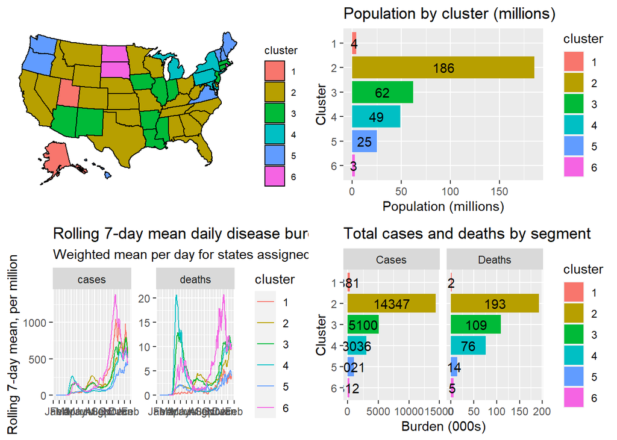

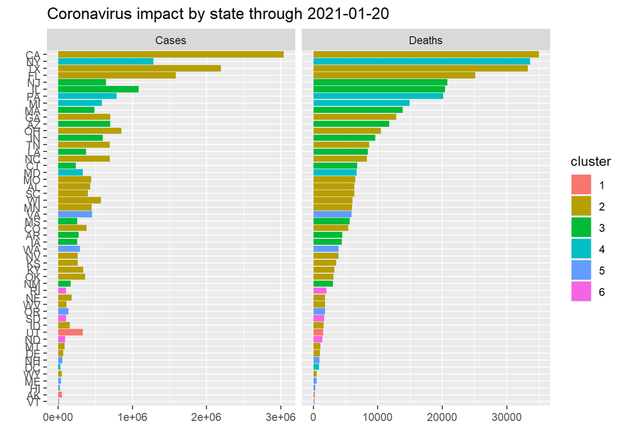

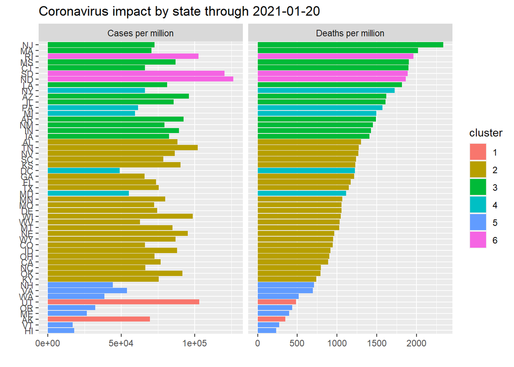

```
##
## Recency is defined as 2020-12-23 through current
##
## Recency is defined as 2020-12-23 through current
```

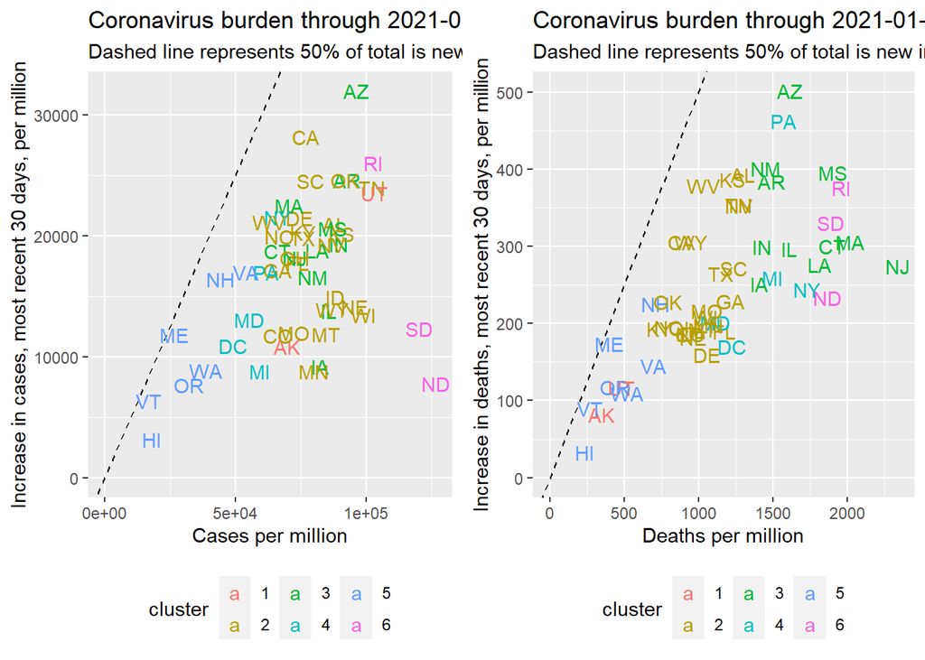

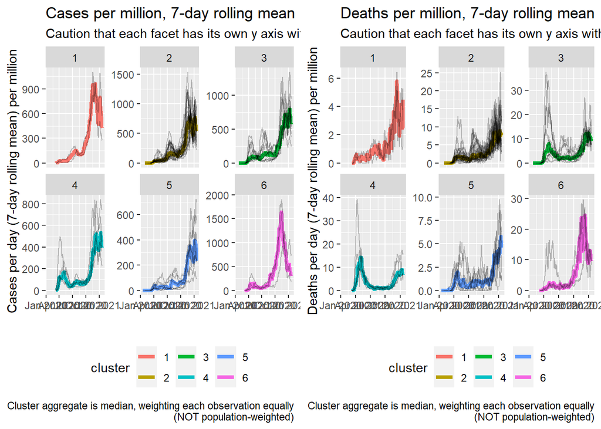

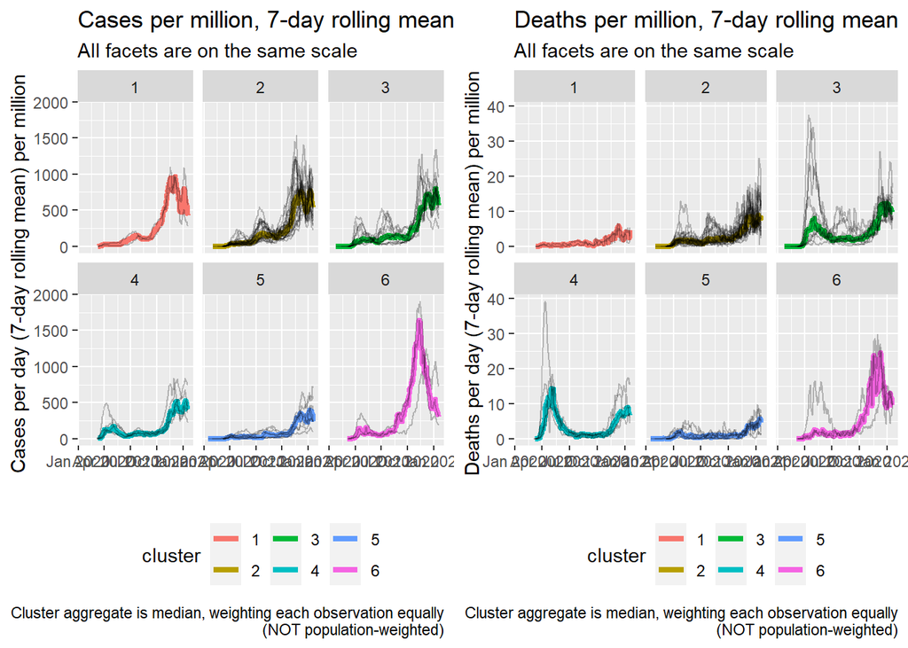

```r
# Example for running assessClusters
plotDataHier3 <- assessClusters(cutree(clHier3, k=6),
                                dfState=pop_2019,
                                dfBurden=dfPer3,
                                thruLabel="2021-01-20",
                                plotsTogether=TRUE
                                )
```

The plotConsolidatedMetrics() function is copied:

```r
# Function to create plots of consolidated metrics
plotConsolidatedMetrics <- function(dfMain,
                                    dfHosp=NULL,
                                    varMain=c("state", "cluster", "date", "pop", "cases", "deaths", "hosp"),
                                    varDropHosp=c("n", "pop"),
                                    joinBy=c("state", "cluster", "date"),
                                    subT=NULL,
                                    nrowPlot2=1
                                    ) {

    # FUNCTION ARGUMENTS:
    # dfMain: the main file produced by assessClusters(), containing data by state-cluster-date
    # dfHosp: the separate file with hospital data (NULL means data already available in dfMain)
    # varMain: variables to keep from dfMain
    # varDropHosp: variables to drop from dfHosp
    # joinBy: variables for joining dfMain and dfHosp
    # subT: plot subtitle (NULL will use the defaults),
    # nrowPlot2: number of rows for the facetting to use on plot 2

    if (is.null(subT)) {
        subT <- "Cases: new cases, Deaths: new deaths, Hosp: total in hospital (not new)"
    }

    # Filter dfMain to include only variables in varMain
    dfMain <- dfMain %>%
        select_at(vars(all_of(varMain)))

    # Left join dfMain to dfHosp unless dfHosp is NULL
    if (!is.null(dfHosp)) {
        dfHosp <- dfHosp %>%
            select_at(vars(all_of(names(dfHosp)[!(names(dfHosp) %in% varDropHosp)])))
        dfMain <- dfMain %>%
            left_join(dfHosp, by=all_of(joinBy))
    }

    # Check that variables state, cluster, date, pop are all available
    if (!(c("state", "cluster", "date", "pop") %in% names(dfMain) %>% all())) {
        stop("\nFunction requires variables state, cluster, date, and pop after processing\n")
    }

    # Create the relevant plotting data
    dfPlot <- dfMain %>%
        pivot_longer(-c(state, cluster, date, pop)) %>%
        filter(!is.na(value)) %>%
        rbind(mutate(., state="cluster")) %>%
        group_by_at(vars(all_of(c(joinBy, "name")))) %>%
        summarize(value=sum(value), pop=sum(pop), .groups="drop") %>%
        mutate(vpm=1000000*value/pop) %>%
        arrange(state, cluster, name, date) %>%
        group_by(state, cluster, name) %>%
        helperRollingAgg(origVar="vpm", newName="vpm7")

    # Create facetted plots for totals by metric by segment
    p1 <- dfPlot %>%
        filter(!is.na(vpm7)) %>%
        ggplot(aes(x=date, y=vpm7)) +
        geom_line(data=~filter(., state=="cluster"), aes(group=cluster, color=cluster), lwd=1.5) +
        geom_line(data=~filter(., state!="cluster"), aes(group=state), alpha=0.25) +
        facet_grid(name ~ cluster, scales="free_y") +
        labs(x="",
             y="Rolling 7-day mean per million",
             title="Key metrics by cluster (7-day rolling mean per million)",
             subtitle=subT
        ) +
        scale_x_date(date_breaks="1 months", date_labels="%b") +
        theme(axis.text.x=element_text(angle=90))
    print(p1)

    # Create all-segment plot by metric
    p2 <- dfPlot %>%
        filter(!is.na(vpm7)) %>%
        ggplot(aes(x=date, y=vpm7)) +
        geom_line(data=~filter(., state=="cluster"), aes(group=cluster, color=cluster), lwd=1.5) +
        facet_wrap(~ name, scales="free_y", nrow=nrowPlot2) +
        labs(x="",
             y="Rolling 7-day mean per million",
             title="Key metrics by cluster (7-day rolling mean per million)",
             subtitle=subT
        ) +
        scale_x_date(date_breaks="1 months", date_labels="%b") +
        theme(axis.text.x=element_text(angle=90))
    print(p2)

    # Create all-metric plot by segment (define 100% as peak for segment-metric)
    p3 <- dfPlot %>%
        filter(!is.na(vpm7)) %>%
        group_by(state, cluster, name) %>%
        mutate(spm7=vpm7/max(vpm7)) %>%
        ggplot(aes(x=date, y=spm7)) +
        geom_line(data=~filter(., state=="cluster"), aes(group=name, color=name), lwd=1) +
        facet_wrap(~ cluster, scales="free_y") +
        labs(x="",
             y="% of Maximum",
             title="Key metrics by cluster (% of cluster maximum for variable)",
             subtitle=subT
        ) +
        scale_x_date(date_breaks="1 months", date_labels="%b") +
        scale_color_discrete("variable") +
        theme(axis.text.x=element_text(angle=90))
    print(p3)

    # Return the plotting data
    dfPlot

}
```

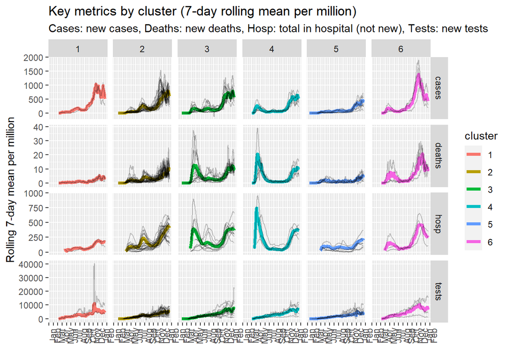

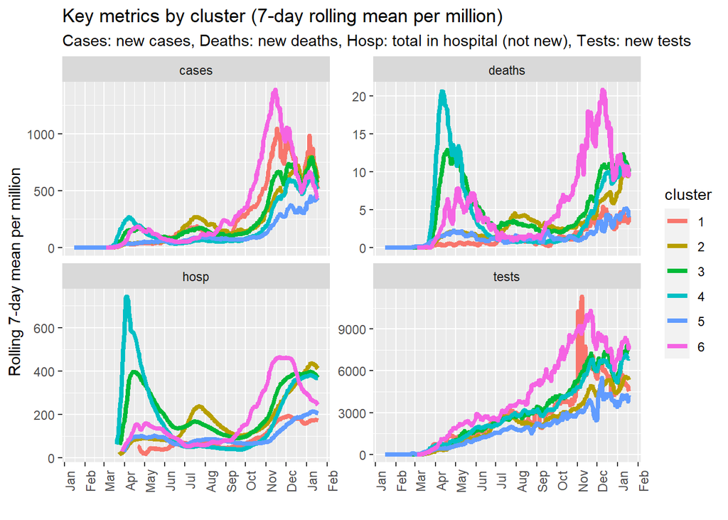

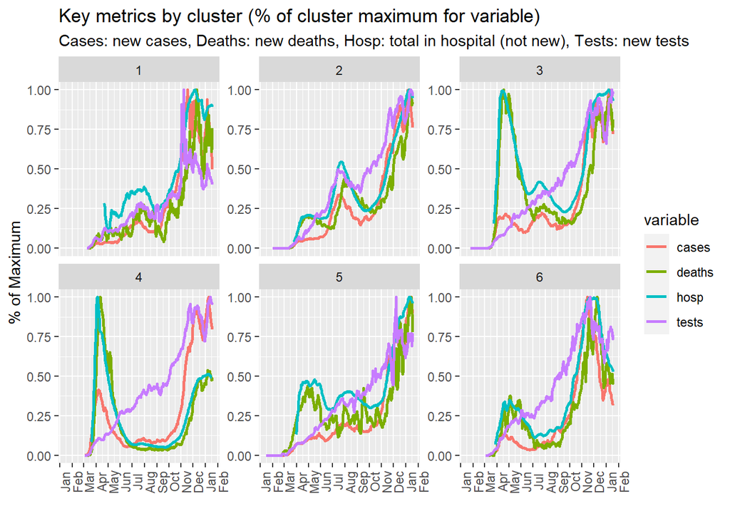

```r
# Example for consolidatedPlotData()
subT <- "Cases: new cases, Deaths: new deaths, Hosp: total in hospital (not new), Tests: new tests"
consolidatedPlotDataHier3 <- plotConsolidatedMetrics(plotDataHier3,
                                                     varMain=c("state", "cluster", "date", "pop",
                                                               "cases", "deaths", "hosp", "tests"
                                                               ),
                                                     subT=subT,
                                                     nrowPlot2=2
                                                     )
```

The makeCumulative() and plotCumulative() functions are copied:

```r
# Function to convert a file to cumulative totals
makeCumulative <- function(df,
                           typeVar="name",
                           typeKeep=c("cases", "deaths", "tests"),
                           valVar="vpm7",
                           groupVars=c("state", "cluster", "name"),
                           arrangeVars=c("date"),
                           newName="cum7"
                           ) {

    # FUNCTION ARGUMENTS:
    # df: data frame containing the metrics
    # typeVar: the variable holding the metric type (default is 'name')
    # typeKeep: the values of typeVar to be kept
    # valVar: the variable holding the metric value (default is 'vpm7')
    # groupVars: groups for calculating cumulative sum
    # arrangeVars: variables to be sorted by before calculating cumulative sum
    # newName: the name for the new variable

    # Create the cumulative data
    dfCum <- df %>%
        filter(get(typeVar) %in% typeKeep, !is.na(get(valVar))) %>%
        arrange_at(vars(all_of(c(groupVars, arrangeVars)))) %>%
        group_by_at(groupVars) %>%
        mutate(!!newName:=cumsum(get(valVar))) %>%
        ungroup()

    # Return the processed data
    dfCum

}



# Function to plot cumulative data
plotCumulativeData <- function(df,
                               keyMetricp2,
                               flagsp2,
                               p2Desc=keyMetricp2,
                               keyVar="cum7",
                               makep1=FALSE,
                               makep2=TRUE
                               ) {

    # FUNCTION ARGUMENTS:
    # df: the data frame of cumulative data
    # keyMetricp2: the key metric to be plotted in the second plot (e.g., "deaths", "cases", "tests")
    # flagsp2: states to be treated as flagged in the second plot
    # p2Desc: the description to be used in plot 2
    # keyVar: the key variable to plot
    # makep1: boolean, whether to make the first plot
    # makep2: boolean, whether to make the second plot

    # Plot the cumulative data by cluster (if flag is set for producing this)
    if (isTRUE(makep1)) {
        p1 <- df %>%
            filter(state=="cluster") %>%
            ggplot(aes(x=date, y=get(keyVar))) +
            geom_line(aes(group=cluster, color=cluster)) +
            facet_wrap(~name, nrow=1, scales="free_y") +
            scale_x_date(date_breaks="1 months", date_labels="%m") +
            labs(x="Month",
                 y="Cumulative Burden (per million)",
                 title="Cumulative burden by segment (per million)"
            )
        print(p1)
    }


    # Plot the cumulative totals over time for one metric, and flag the highest
    if (isTRUE(makep2)) {
        p2 <- df %>%
            filter(state!="cluster", name==keyMetricp2) %>%
            mutate(bold=ifelse(state %in% flagsp2, 1, 0)) %>%
            ggplot(aes(x=date, y=get(keyVar))) +
            geom_line(aes(group=state, color=cluster, alpha=0.4+0.6*bold, size=0.5+0.5*bold)) +
            geom_text(data=~filter(., bold==1, date==max(date)),
                      aes(x=date+lubridate::days(10),
                          label=paste0(state, ": ", round(get(keyVar), 0)),
                          color=cluster
                      ),
                      size=3,
                      fontface="bold"
            ) +
            scale_x_date(date_breaks="1 months", date_labels="%m") +
            scale_alpha_identity() +
            scale_size_identity() +
            labs(x="Month",
                 y=paste0("Cumulative ", p2Desc, " (per million)"),
                 title=paste0("Cumulative coronavirus ", p2Desc, " by state (per million)"),
                 subtitle="Top 5 states for total and growth rate are bolded and labelled"
            )
        print(p2)
    }

}


# Function to find and flag states that are high on a key value or change in key value
findFlagStates <- function(df,
                           keyMetricVal,
                           keyMetricVar="name",
                           cumVar="cum7",
                           prevDays=30,
                           nFlag=5
                           ) {

    # FUNCTION ARGUMENTS:
    # df: the data frame containing the cumulative data
    # keyMetricVal: the metric of interest (e.g., "deaths", "cases", "tests")
    # keyMetricVar: the variable name for the column containing the metric of interest
    # cumVar: variable containing the cumulative totals
    # prevDays: the number of days previous to use for defining growth
    # nFlag: the number of states to flag for either total or growth (top-n of each)

    # Find top-5 in either total or recent increase
    dfFlag <- df %>%
        filter(get(keyMetricVar)==keyMetricVal, state!="cluster") %>%
        select_at(vars(all_of(c("state", "date", cumVar)))) %>%
        group_by(state) %>%
        summarize(maxVal=max(get(cumVar)),
                  tminus=sum(ifelse(date==max(date)-lubridate::days(prevDays), get(cumVar), 0)),
                  .groups="drop"
        ) %>%
        ungroup() %>%
        mutate(growth=maxVal-tminus,
               rkTotal=min_rank(-maxVal),
               rkGrowth=min_rank(-growth),
               flag=ifelse(pmin(rkTotal, rkGrowth)<=nFlag, 1, 0)
        ) %>%
        arrange(-flag, rkTotal)

    # Return the top values as a vector of states
    dfFlag %>%
        filter(flag==1) %>%
        pull(state)

}
```

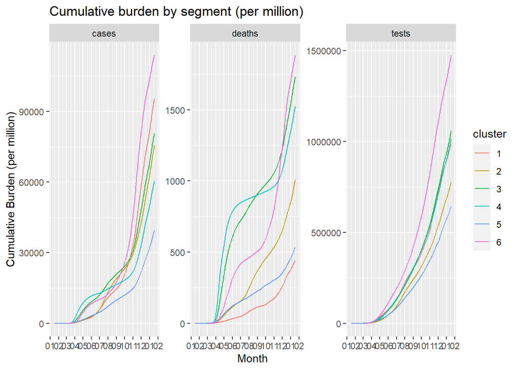

```r
consPosHier3 <- consolidatedPlotDataHier3 %>%
    ungroup() %>%
    select(state, cluster, date, name, vpm7) %>%
    arrange(state, cluster, date, name) %>%
    pivot_wider(-vpm7, names_from="name", values_from="vpm7") %>%
    mutate(pctpos=cases/tests) %>%
    pivot_longer(-c(state, cluster, date), values_to="vpm7") %>%
    filter(!is.na(vpm7))

clCumHier3 <- makeCumulative(consPosHier3)

plotCumulativeData(clCumHier3,
                   keyMetricp2="",
                   flagsp2="",
                   makep1=TRUE,
                   makep2=FALSE
                   )
```

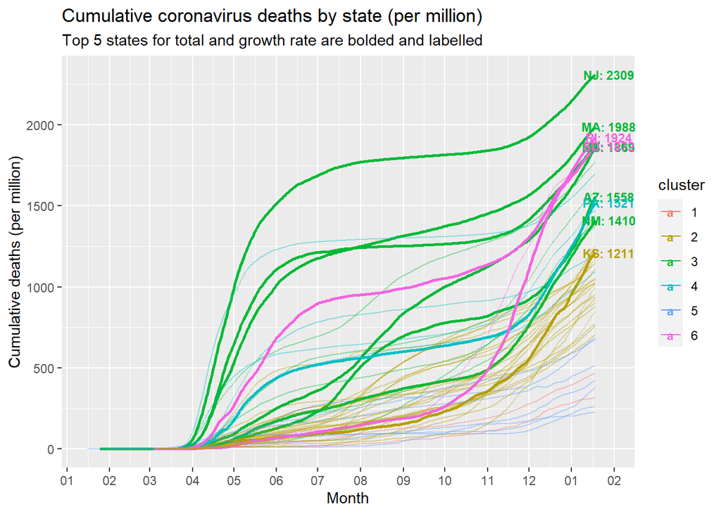

```r
plotCumulativeData(clCumHier3,
                   keyMetricp2="deaths",
                   flagsp2=findFlagStates(clCumHier3, keyMetricVal = "deaths")
                   )
```

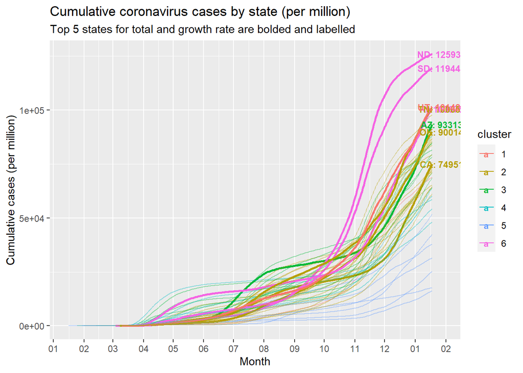

```r
plotCumulativeData(clCumHier3,
                   keyMetricp2="cases",
                   flagsp2=findFlagStates(clCumHier3, keyMetricVal = "cases")
                   )
```

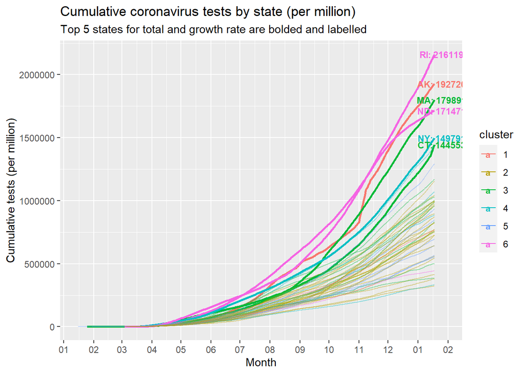

```r
plotCumulativeData(clCumHier3,
                   keyMetricp2="tests",
                   flagsp2=findFlagStates(clCumHier3, keyMetricVal = "tests")
                   )
```

The functions appear to all be working for 2021 data from COVID Tracking Project. Next steps are to try the integrated function on the latest data.

The integrated function is run using data downloaded on 26-JAN-2021, with a similar approach as previous:

```r
# Create new segments with updated data
locDownload <- "./RInputFiles/Coronavirus/CV_downloaded_210126.csv"
ctp_hier7_210126 <- readRunCOVIDTrackingProject(thruLabel="Jan 25, 2021",
                                                downloadTo=if(file.exists(locDownload)) NULL else locDownload,
                                                readFrom=locDownload,
                                                compareFile=readFromRDS("test_hier5_201025")$dfRaw,
                                                hierarchical=TRUE,
                                                reAssignState=list("HI"="ME"),
                                                kCut=8,
                                                minShape=3,
                                                ratioDeathvsCase = 5,
                                                ratioTotalvsShape = 0.25,
                                                minDeath=100,
                                                minCase=10000
                                                )
```

```
##
## File is unique by state and date
##
##
## Overall control totals in file:
## # A tibble: 1 x 3
##   positiveIncrease deathIncrease hospitalizedCurrently
##              <dbl>         <dbl>                 <dbl>
## 1         24935041        411823              17790757
##
## *** COMPARISONS TO REFERENCE FILE: compareFile
##
## Checking for similarity of: column names
## In reference but not in current:
## In current but not in reference:
```

[output cut: 201 more lines]

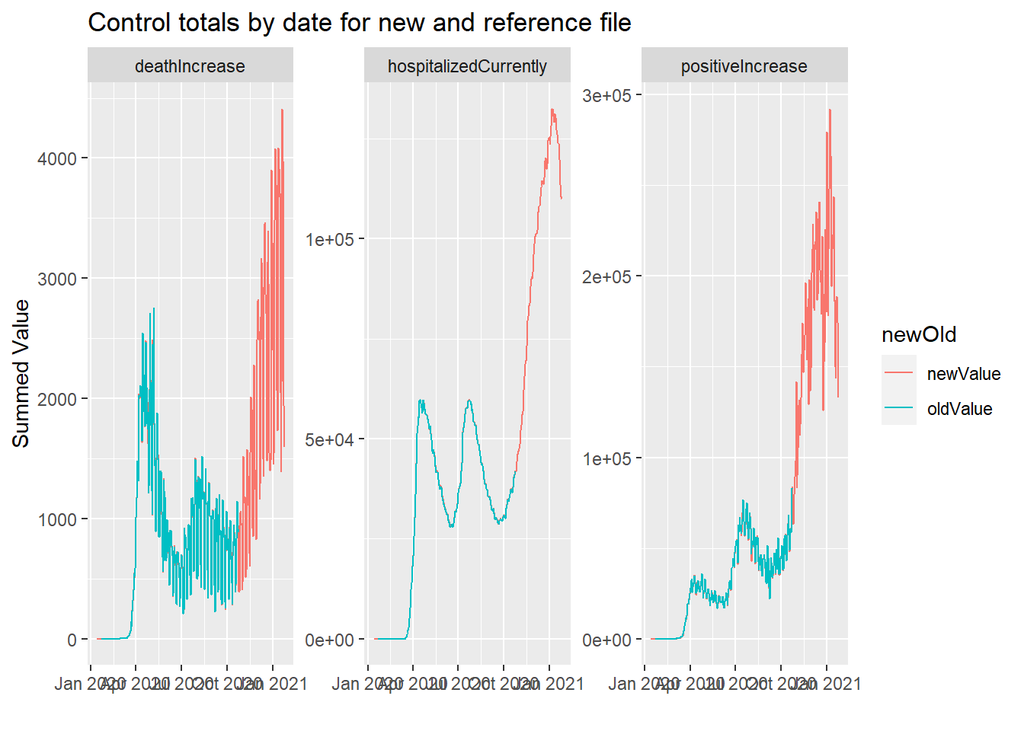

[output not shown]

[output cut: 91 more lines]

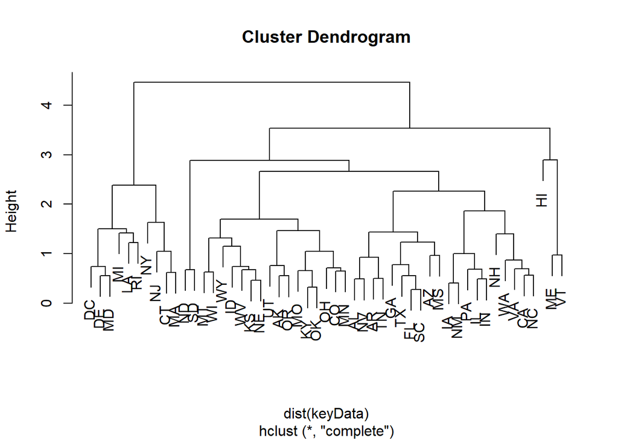

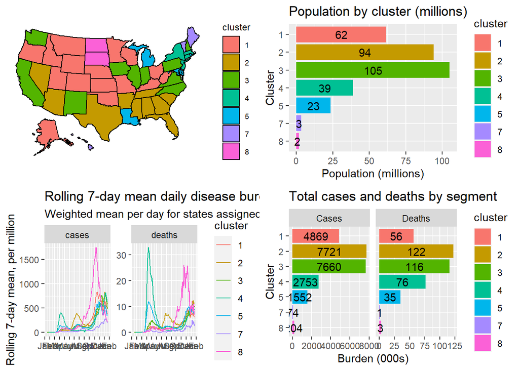

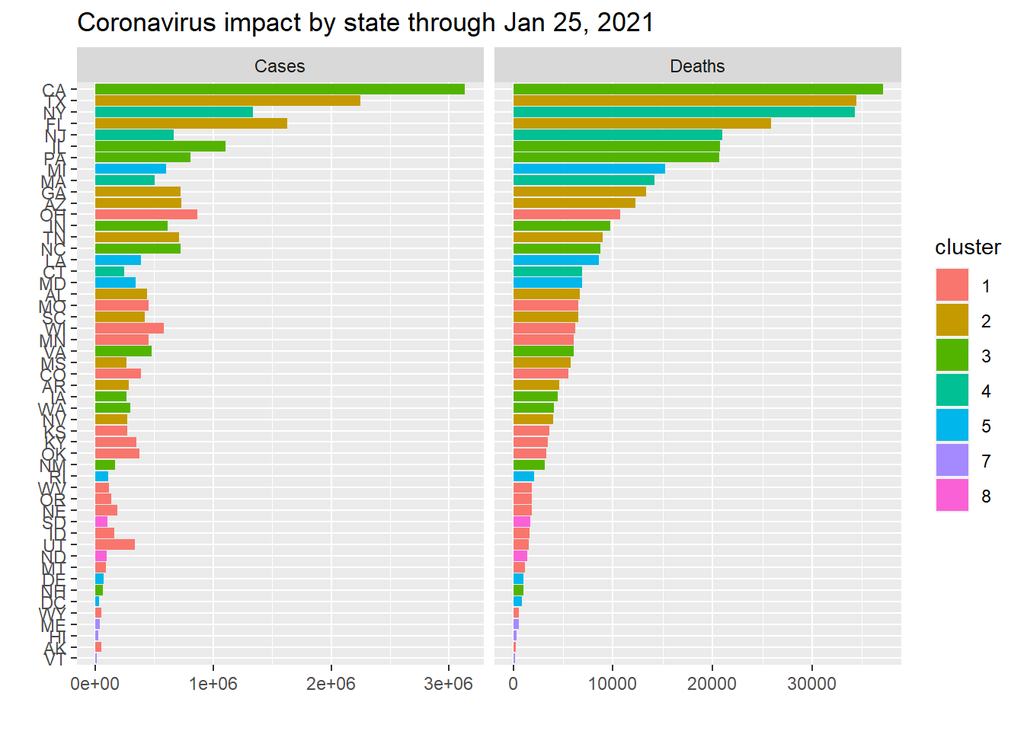

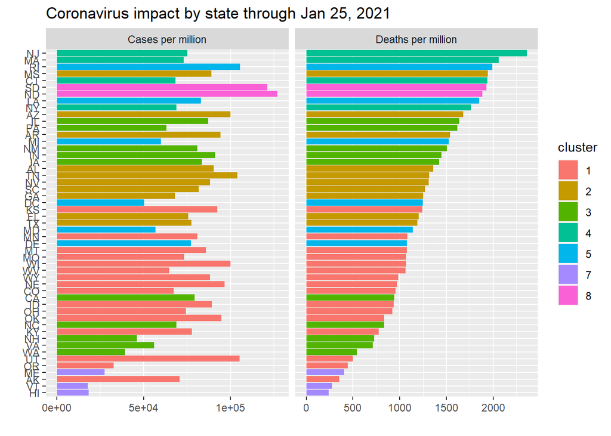

```
##
## Recency is defined as 2020-12-27 through current
##
## Recency is defined as 2020-12-27 through current
```

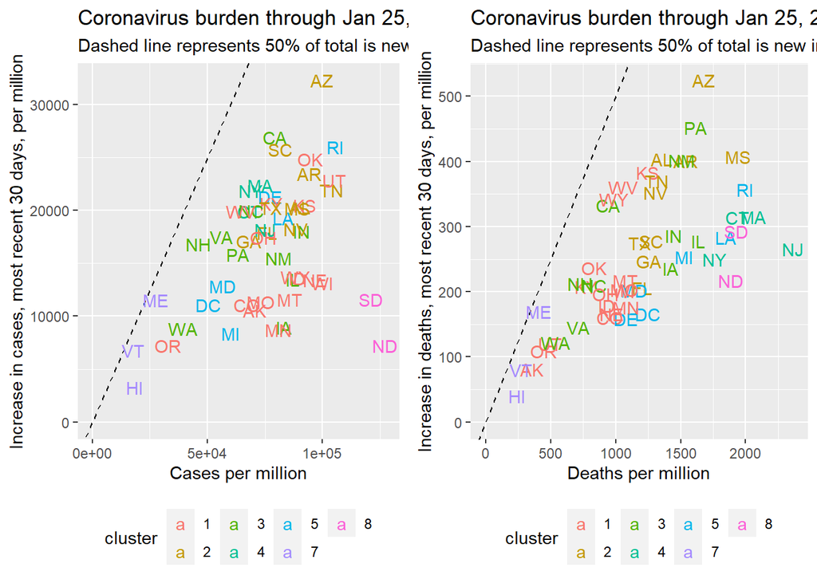

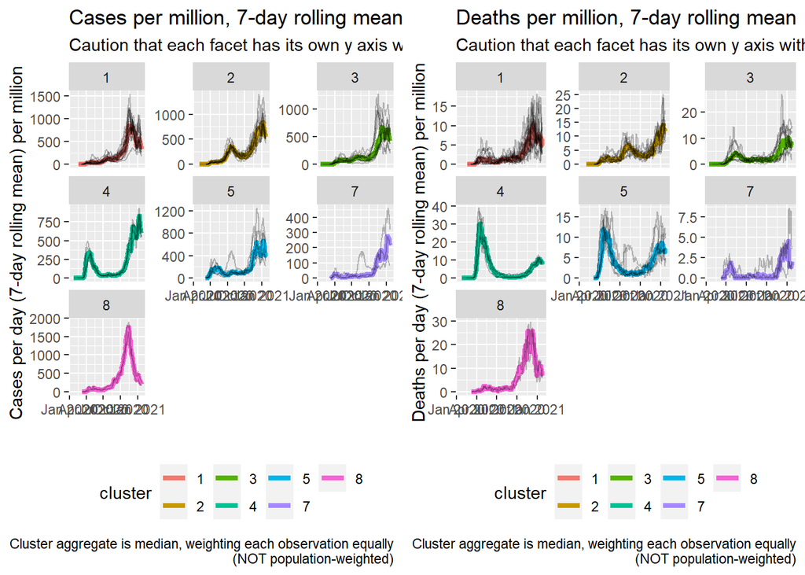

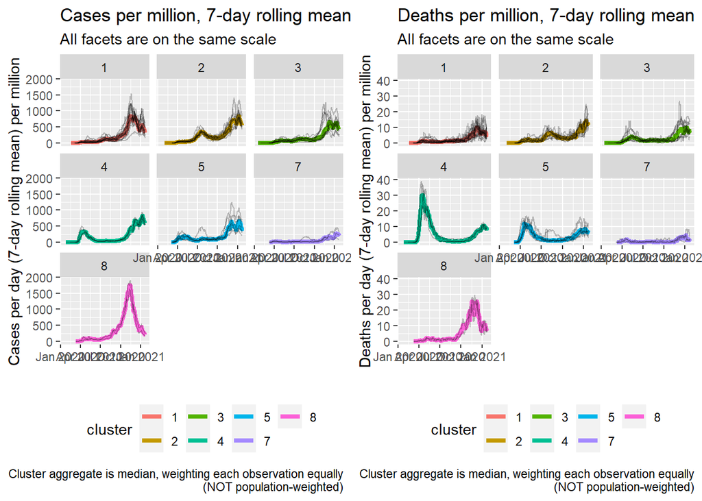

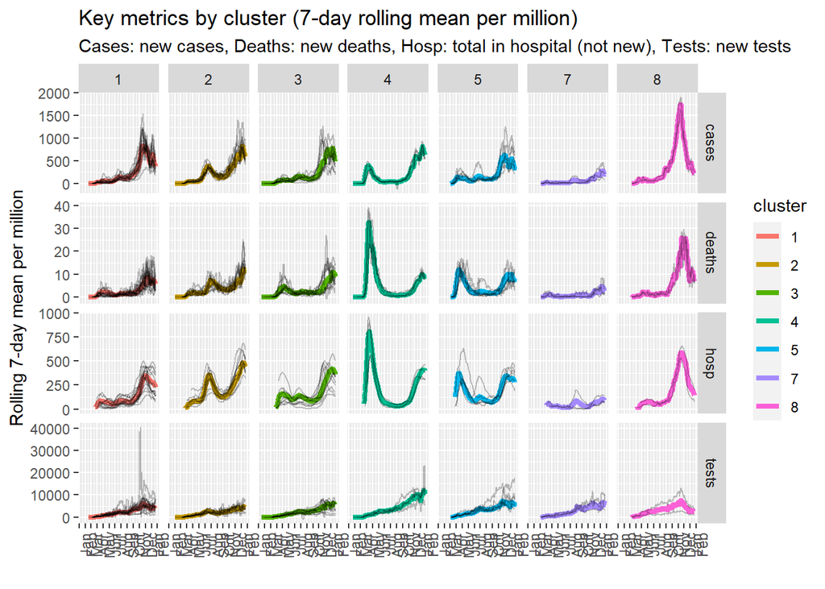

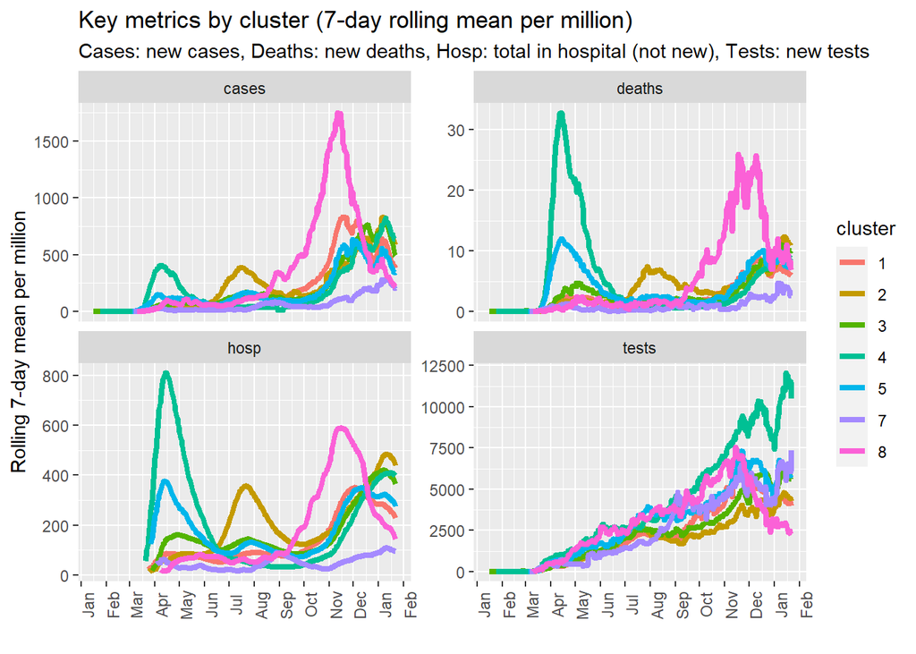

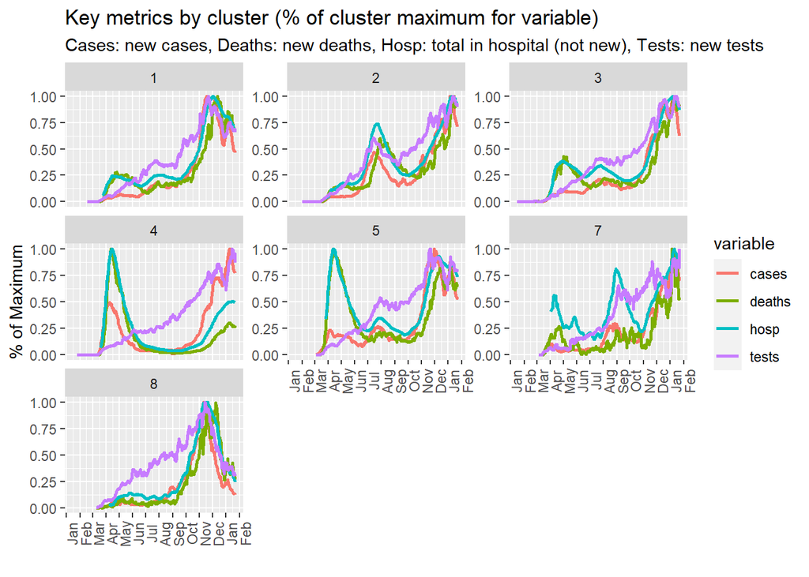